# Vehicles in the park

# Items being judged

The judgement data uses ID numbers for the various items being judged. This table shows how these IDs correspond to the actual items:

```r
items <- read_csv(here::here("data-raw/item_details.csv")) %>% mutate(item_description = str_trim(item_description))

items
```

| item_num | item_name | item_description |
| --- | --- | --- |
| 1 | Airplane | Airplane |
| 2 | Ambulance | Ambulance |
| 3 | Automobile | Automobile |
| 4 | Baby Shoulder-Carrier | Baby shoulder-carrier |
| 5 | Baby Stroller | Baby stroller |
| 6 | Bicycle | Bicycle |
| 7 | Bus | Bus |
| 8 | Canoe | Wooden canoe |
| 9 | Car | Car |
| 10 | Carriage | Horse-drawn carriage |

[output cut: 16 more lines]

# Judgement data

```r
judgement_data <- read_csv(here::here("data-raw", "judgements_all.csv"))

# restrict to the binary judgement data
# (some of the judges used a slider to provide a score rather than a binary choice)
judgement_data <- judgement_data %>%
  filter(!is.na(won)) %>%
  select(-any_of("score"))
```

Data summary:

```r
judgement_data %>%
  group_by(study) %>%
  summarise(
    n_judges = n_distinct(judge_id),
    n_judgements = n_distinct(judgement_id)
  )
```

| study | n_judges | n_judgements |
| --- | --- | --- |
| nuisance_pairs | 20 | 2000 |
| vehicle_pairs | 22 | 2200 |
| violation_pairs | 19 | 1831 |

Judges had to complete attention checks - when item 0 appeared, they were instructed to select that as the winner.

Here we identify those judges who failed any of the attention checks:

```r
judgement_data %>%
  mutate(attention_check = case_when(
    (left == 0 | right == 0) & won == 0 ~ "pass",
    (left == 0 | right == 0) & won != 0 ~ "fail",
    TRUE ~ NA_character_
  )) %>%
  group_by(judge_id) %>%
  summarise(
    failed_attention_checks = sum(attention_check == "fail", na.rm = TRUE)
  ) %>%
  filter(failed_attention_checks > 0)
```

| judge_id | failed_attention_checks |
| --- | --- |
| 59 | 5 |
| 103 | 1 |
| 110 | 2 |
| 159 | 1 |
| 163 | 1 |

For the analysis, we remove all the attention checks, and also all data from those judges who failed 2 or more of the attention checks.

```r
decisions <- judgement_data %>%
  filter(left != 0, right != 0) %>%
  filter(!judge_id %in% c(59, 110))
```

This leaves the following set of judgements:

```r
decisions %>%
  group_by(study) %>%
  summarise(
    n_judges = n_distinct(judge_id),
    n_judgements = n_distinct(judgement_id)
  )
```

| study | n_judges | n_judgements |
| --- | --- | --- |
| nuisance_pairs | 20 | 1900 |
| vehicle_pairs | 21 | 1995 |
| violation_pairs | 18 | 1645 |

# Fit the Bradley-Terry model

We fit the Bradley-Terry model separately for each study.

```r
btm_results %>%
  select(-csv_content, -btm_estimates, -judge_fits) %>%
  mutate(ssr = as.numeric(ssr)) %>%
  arrange(study)
```

| study | N_R | N_A | N_C | ssr |
| --- | --- | --- | --- | --- |
| nuisance_pairs | 25 | 20 | 1900 | 0.9799978 |
| vehicle_pairs | 25 | 21 | 1995 | 0.9893486 |
| violation_pairs | 25 | 18 | 1645 | 0.9832530 |

```r
btm_estimates <- btm_results %>%
  select(study, btm_estimates) %>%
  unnest(cols = c(btm_estimates)) %>%
  select(-id) %>%
  # For clarity, include the item names corresponding to the ID numbers
  left_join(items %>% select(individual = item_num, item_name), by = "individual") %>%
  relocate(item_name, .after = individual)
```

The estimated scores for each item are written to `data-processed/btm_estimates.csv`.

```r
btm_estimates %>%
  write_csv(here::here("data-processed/btm_estimates.csv"))
```

We also produce a simplified version that just includes the theta (_est) and se.theta (_se) for each of the scales, saved in `data-processed/scores.csv`.

```r
scores <- btm_estimates %>%
  # remove redundant text from the study names
  mutate(study = str_remove(study, "_pairs")) %>%
  # focus only on the relevant columns
  select(study, individual, item_name, est = theta, se = se.theta) %>%
  # create separate _est and _se columns for each study
  pivot_wider(
    names_from = study,
    names_glue = "{study}_{.value}",
    values_from = c(est, se)
  )

scores
```

| individual | item_name | nuisance_est | vehicle_est | violation_est | nuisance_se | vehicle_se | violation_se |
| --- | --- | --- | --- | --- | --- | --- | --- |
| 22 | Truck | 2.3753875 | 3.56818705 | 3.70464674 | 0.2492220 | 0.3187811 | 0.3770248 |
| 14 | Helicopter | 2.1365008 | 1.18115975 | 1.86446251 | 0.2348185 | 0.2630020 | 0.2765370 |
| 7 | Bus | 2.0939810 | 3.63409124 | 3.03961076 | 0.2407744 | 0.3116179 | 0.3162993 |
| 1 | Airplane | 1.9507478 | 1.99187342 | 2.00028212 | 0.2390358 | 0.2720872 | 0.2875034 |
| 3 | Automobile | 1.4725333 | 3.68194555 | 2.62725636 | 0.2132543 | 0.3049798 | 0.2897540 |
| 15 | Vehicle | 1.4630198 | 3.91317117 | 3.06200533 | 0.2176885 | 0.3341861 | 0.3164476 |
| 17 | Moped | 1.4801032 | 1.54246232 | 1.43140579 | 0.2161980 | 0.2749831 | 0.2612191 |
| 9 | Car | 1.2353504 | 5.15104652 | 2.82869290 | 0.2119117 | 0.4349583 | 0.2951870 |
| 12 | Drone | 0.9786769 | -2.82034886 | -0.85207535 | 0.2053920 | 0.2632260 | 0.2334831 |
| 10 | Carriage | 0.5111787 | 0.30088600 | 0.80757574 | 0.2012828 | 0.2489738 | 0.2556846 |

[output cut: 15 more lines]

```r
scores %>%
  write_csv(here::here("data-processed/scores.csv"))
```

### Interlude: Judge fits

The model gives an infit figure for each judge. This code identifies judges who are more than 2 SDs above the mean.

```r
judge_fits <- btm_results %>%
  select(study, judge_fits) %>%
  unnest(cols = c(judge_fits))

judge_fits %>%
  group_by(study) %>%
  count(discard)
```

| study | discard | n |
| --- | --- | --- |
| nuisance_pairs | FALSE | 19 |
| nuisance_pairs | TRUE | 1 |
| vehicle_pairs | FALSE | 20 |
| vehicle_pairs | TRUE | 1 |
| violation_pairs | FALSE | 17 |
| violation_pairs | TRUE | 1 |

```r
judge_fits %>%
  filter(discard == TRUE)
```

| study | judge_id | infit | infit_mean | infit_sd | discard |
| --- | --- | --- | --- | --- | --- |
| nuisance_pairs | 89 | 1.674933 | 0.9886657 | 0.2875821 | TRUE |
| vehicle_pairs | 113 | 2.071098 | 0.9363319 | 0.3512433 | TRUE |
| violation_pairs | 168 | 2.290469 | 1.0091719 | 0.3796662 | TRUE |

This plot shows the infit score for each judge:

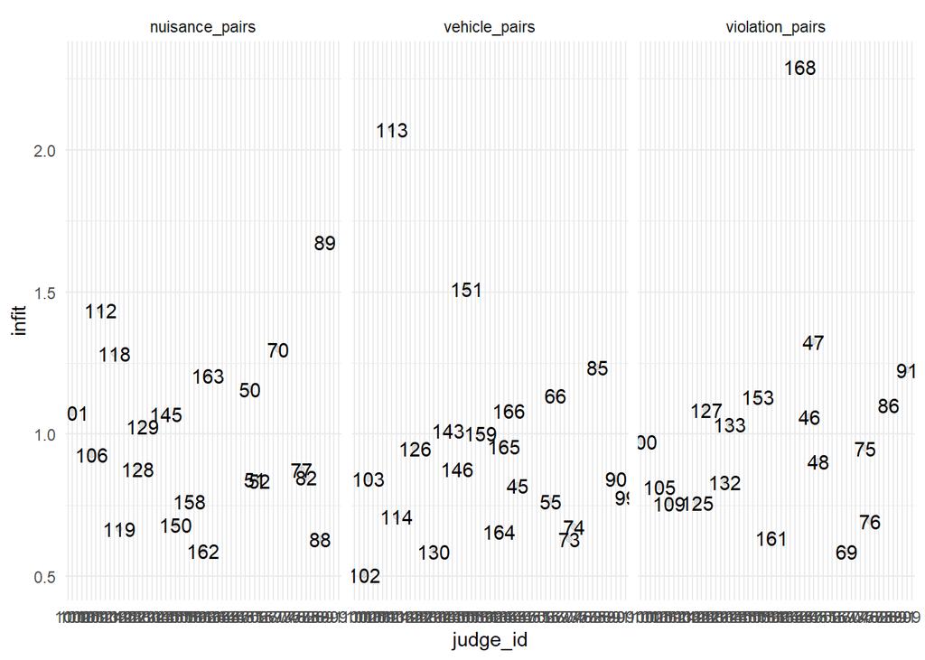

```r
judge_fits %>%
  ggplot(aes(y = infit, x = judge_id)) +
  geom_point(alpha = 0.1) +
  geom_text(aes(label = judge_id)) +
  facet_grid(cols = vars(study))
```

Since very few judges are misfitting, we have decided not to remove their data.

### Interlude 2: “Every judge saw every item multiple times”

Here we check how many times each judge saw each item, and focus attention on the judge/item pairings that occurred the least:

```r
decisions %>%
  select(judge_id, left, right) %>%
  pivot_longer(c(left, right), values_to = "item") %>%
  select(judge_id, item) %>%
  group_by(judge_id, item) %>%
  tally() %>%
  ungroup() %>%
  complete(judge_id, item) %>%
  arrange(n) %>%
  head(n = 20)
```

| judge_id | item | n |
| --- | --- | --- |
| 168 | 6 | 1 |
| 168 | 8 | 1 |
| 168 | 10 | 1 |
| 168 | 15 | 1 |
| 168 | 22 | 1 |
| 168 | 24 | 1 |
| 168 | 25 | 1 |
| 51 | 23 | 2 |
| 91 | 24 | 2 |
| 125 | 14 | 2 |

[output cut: 10 more lines]

This shows that almost all judges saw every item at least twice. However it looks like judge 168 only saw some items once.

# Next: analysis

The analysis is carried out in a separate script, `02-analyse-scales`.